# Predicting How Well Barbell Lifts Are Performed

Maitreya Tarmale

September 19, 2026

# Overview

Wearable devices make it easy to measure *how much* of an activity people do, but rarely *how well* they do it. In this project I use accelerometer data from the belt, forearm, arm and dumbbell of 6 participants who lifted a barbell correctly and incorrectly in 5 ways. The goal is to predict the manner of the exercise, the `classe` variable (A = correct form, B to E = four common mistakes), from the sensor readings.

I clean the data, hold out a validation set, fit a baseline decision tree and a random forest with 5-fold cross-validation, estimate the out-of-sample error on the held-out data, and use the final model to predict the 20 test cases.

Data source: Velloso, E., Bulling, A., Gellersen, H., Ugulino, W., Fuks, H. *Qualitative Activity Recognition of Weight Lifting Exercises.* Proceedings of the 4th International Conference in Cooperation with SIGCHI (Augmented Human ’13), Stuttgart, 2013.

# Loading the data

```r
library(caret)
library(randomForest)
library(rpart)

train_file <- "pml-training.csv"
test_file  <- "pml-testing.csv"
train_url  <- "https://d396qusza40orc.cloudfront.net/predmachlearn/pml-training.csv"
test_url   <- "https://d396qusza40orc.cloudfront.net/predmachlearn/pml-testing.csv"

# Download only if the files are not already in the working folder
if (!file.exists(train_file)) download.file(train_url, train_file)
if (!file.exists(test_file))  download.file(test_url,  test_file)

na_codes <- c("NA", "", "#DIV/0!")
raw      <- read.csv(train_file, na.strings = na_codes)
test_raw <- read.csv(test_file,  na.strings = na_codes)
dim(raw)
```

```
## [1] 19622   160
```

The training file has 19622 rows and 160 columns, and the test file has 20 rows (the 20 cases to predict).

# Cleaning the data

I made three cleaning choices:

1. **Removed the first 7 columns** (row index, user name, timestamps and window markers). These identify *who* and *when*, not *how* the lift was done, and using them would let a model “cheat” on this dataset instead of learning movement patterns.
2. **Removed columns that are mostly missing** (more than 90% `NA`). These are summary statistics that exist only for a few rows, and the 20 test cases have them empty anyway.
3. **Removed near-zero-variance predictors**, which carry almost no information.

```r
raw      <- raw[, -(1:7)]
test_raw <- test_raw[, -(1:7)]

keep <- colMeans(is.na(raw)) < 0.9
raw  <- raw[, keep]

predictor_cols <- setdiff(names(raw), "classe")
nzv <- nearZeroVar(raw[, predictor_cols])
if (length(nzv) > 0) raw <- raw[, -nzv]

raw$classe <- factor(raw$classe)
predictor_cols <- setdiff(names(raw), "classe")
test_x <- test_raw[, predictor_cols]

length(predictor_cols)
```

```
## [1] 52
```

```r
table(raw$classe)
```

```
##
##    A    B    C    D    E
## 5580 3797 3422 3216 3607
```

After cleaning, 52 predictors remain. The five classes are reasonably balanced, with class A the most common.

# Model building and cross-validation

**Validation split.** I set aside 30% of the training data as a validation set that the models never see during training. This gives an honest estimate of the out-of-sample error.

**Cross-validation.** Inside the 70% training part, I used 5-fold cross-validation for both models (`trainControl(method = "cv", number = 5)`). The data are split into 5 parts, the model is trained on 4 and tested on the 5th, and this is repeated so each part is used once for testing. This also lets `train()` pick the best tuning value.

**Why these models.** I started with a single decision tree (`rpart`) as an easy-to-interpret baseline. I then fit a random forest, which averages many trees. Random forests handle many correlated numeric predictors and non-linear patterns well, need little preprocessing (no scaling), and are known to work well on sensor data like this.

```r
set.seed(12345)
in_train   <- createDataPartition(raw$classe, p = 0.7, list = FALSE)
training   <- raw[in_train, ]
validation <- raw[-in_train, ]

ctrl <- trainControl(method = "cv", number = 5)

set.seed(12345)
fit_tree <- train(classe ~ ., data = training, method = "rpart", trControl = ctrl)

set.seed(12345)
fit_rf <- train(classe ~ ., data = training, method = "rf", trControl = ctrl,
                ntree = 100, tuneGrid = data.frame(mtry = c(2, 7, 27)))

fit_rf
```

```
## Random Forest
##
## 13737 samples
##    52 predictor
##     5 classes: 'A', 'B', 'C', 'D', 'E'
##
## No pre-processing
## Resampling: Cross-Validated (5 fold)
## Summary of sample sizes: 10990, 10990, 10989, 10991, 10988
## Resampling results across tuning parameters:
##
##   mtry  Accuracy   Kappa
##    2    0.9911913  0.9888565
##    7    0.9922105  0.9901460
##   27    0.9903903  0.9878435
##
## Accuracy was used to select the optimal model using the largest value.
## The final value used for the model was mtry = 7.
```

# Out-of-sample error

The cross-validated accuracy comes from the 5 folds inside the training data. The validation accuracy comes from the 30% that was held out entirely. Because the validation set was never used for training or tuning, its error is my estimate of the **expected out-of-sample error**.

```r
cm_tree <- confusionMatrix(predict(fit_tree, validation), validation$classe)
cm_rf   <- confusionMatrix(predict(fit_rf,   validation), validation$classe)

results <- data.frame(
  Model = c("Decision tree (rpart)", "Random forest"),
  CV_accuracy         = c(max(fit_tree$results$Accuracy), max(fit_rf$results$Accuracy)),
  Validation_accuracy = c(cm_tree$overall["Accuracy"], cm_rf$overall["Accuracy"])
)
results$Expected_out_of_sample_error <- 1 - results$Validation_accuracy
knitr::kable(results, digits = 4)
```

| Model | CV_accuracy | Validation_accuracy | Expected_out_of_sample_error |
| --- | --- | --- | --- |
| Decision tree (rpart) | 0.5177 | 0.4895 | 0.5105 |
| Random forest | 0.9922 | 0.9968 | 0.0032 |

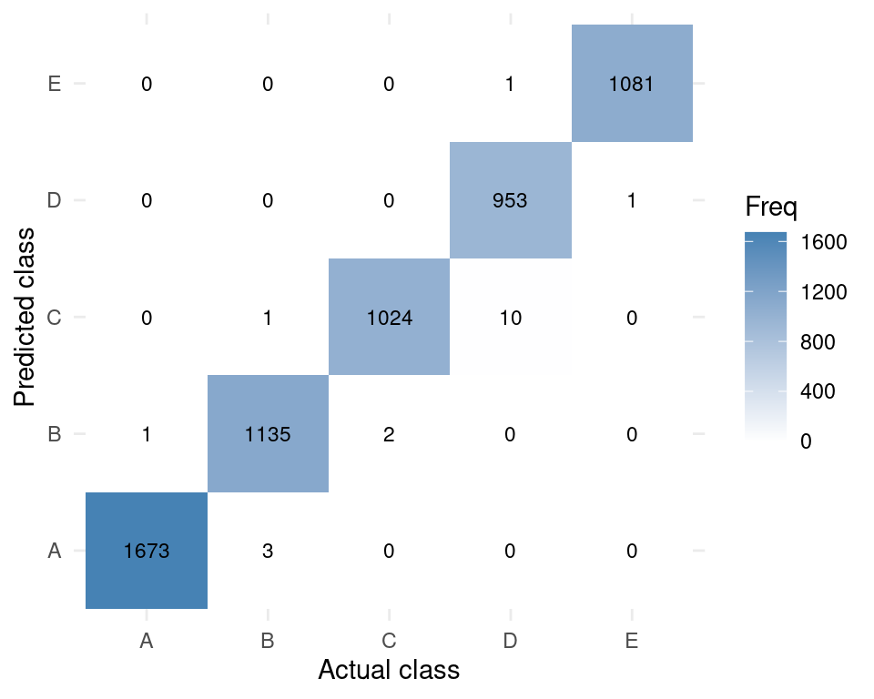

Figure 1: Random forest confusion matrix on the validation set (counts).

```r
library(ggplot2)
cm_df <- as.data.frame(cm_rf$table)
ggplot(cm_df, aes(x = Reference, y = Prediction, fill = Freq)) +
  geom_tile() +
  geom_text(aes(label = Freq), size = 3) +
  scale_fill_gradient(low = "white", high = "steelblue") +
  labs(x = "Actual class", y = "Predicted class") +
  theme_minimal()
```

The random forest reaches a validation accuracy of **0.9968**, so the expected out-of-sample error is about **0.32%**. The decision tree reaches only 0.4895, so the random forest is clearly the better choice here. The cross-validated accuracy (0.9922) agrees closely with the validation accuracy, which suggests the model is not overfitting. Because the final model is fit on 70% of the data and the true error can vary between samples, I would expect the error on new data to be similar, and perhaps slightly higher, especially for new participants not seen in training.

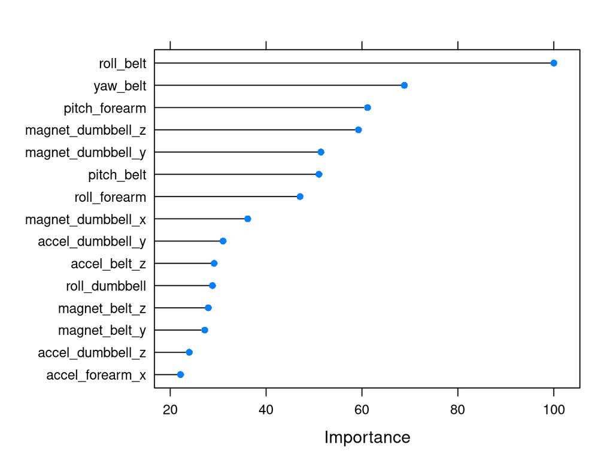

Figure 2: Top 15 most important predictors in the random forest.

```r
imp <- varImp(fit_rf)
plot(imp, top = 15)
```

The most important predictors are readings from the belt, dumbbell and forearm sensors, which makes physical sense since the different mistakes change how the torso, wrist and weight move.

# Predictions for the 20 test cases

I used the random forest to predict the 20 test cases.

```r
pred_test <- predict(fit_rf, test_x)
data.frame(problem_id = test_raw$problem_id, prediction = pred_test)
```

```
##    problem_id prediction
## 1           1          B
## 2           2          A
## 3           3          B
## 4           4          A
## 5           5          A
## 6           6          E
## 7           7          D
## 8           8          B
## 9           9          A
## 10         10          A
## 11         11          B
## 12         12          C
## 13         13          B
## 14         14          A
## 15         15          E
## 16         16          E
## 17         17          A
## 18         18          B
## 19         19          B
## 20         20          B
```

The predictions in order (for the course prediction quiz) are:

```r
as.character(pred_test)
```

```
##  [1] "B" "A" "B" "A" "A" "E" "D" "B" "A" "A" "B" "C" "B" "A" "E" "E" "A" "B" "B" "B"
```

# Conclusion

Cleaning the data to remove identifiers and mostly-empty columns, then fitting a random forest with 5-fold cross-validation, gave a highly accurate model. A separate validation set estimates the out-of-sample error at about 0.32%, and the model was used to predict the 20 test cases.